# TDPL15 Catmandu Workshop

2015-09-14 Poznań

## Catmandu

Created in 2012 by library professionals at Ghent University, Lund University and Bielefeld University.

Currently an international community on all continents with a dozen active submitters.

Used by university libraries, archives, commercial implementers to *extract* metadata records from various sources, *transform* them into new formats and *load* them into databases such as Solr, ElasticSearch, MySQL, PostgreSQL, Oracle, and many more

- http://librecat.org - home page
- https://librecatproject.wordpress.com/ - blog
- librecat-dev@librecat.org - mailing list
- https://github.com/LibreCat/Catmandu - code

## Catmandu @ Bielefeld

[figure not shown]

## Catmandu @ Ghent

[figure not shown]

## Catmandu @ Catalogs

[figure not shown]

## Catmandu @ OpenRefine

[figure not shown]

## Catmandu @ LinkedDataFragments

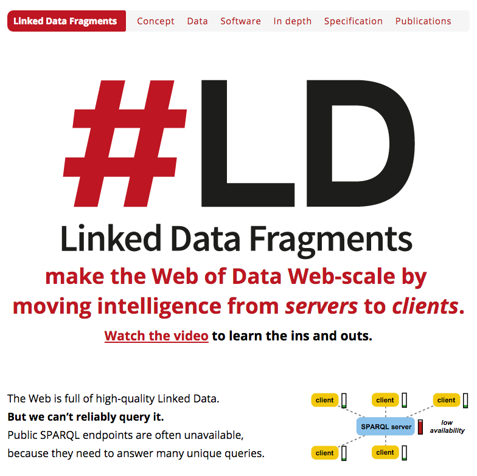

## ELAG presentation & Demo

http://www.slideshare.net/hochstenbach/elag2015

http://ruben.verborgh.org/blog/2015/06/09/federated-sparql-queries-in-your-browser/

http://client.linkeddatafragments.org/

## Virtual Box

[figure not shown]

## Exercise 1

## Catmandu Tools

- Command line tool: catmandu
- Importers: Text, JSON, YAML, CSV, RDF, OAI-PMH, SRU, Z3950, DBI, LDAP, MARC, RIS, Twitter, Wikidata, XLS, …
- Exporters: Text, JSON, YAML, CSV, RDF, MARC, RIS, Template, XLS, XML, …
- Stores: MongoDB, CouchDB, ElasticSearch, Solr, DBI, FedoraCommons, Aleph
- Transformation: Fix or any program that can read and write JSON
- API: Perl
- Web development: PSGI, Dancer

## Catmandu command line tool

```
$ catmandu <COMMAND> <--OPTIONS>
```

```
$ catmandu help
```

```
$ catmandu convert <IMPORTER> to <EXPORTER> < file.yaml
```

```
$ catmandu convert YAML to JSON < file.yaml
```

```
$ catmandu convert YAML to JSON --pretty 1 < file.yaml
```

```
$ catmandu convert CSV --sep_char ';' to JSON < file.csv
```

```
$ catmandu convert YAML to JSON --fix 'retain(title)' < file.yaml
```

## CSV, JSON, YAML

CSV

```
name,organization,country
Nicolas,Ghent University,Belgium
Patrick,Ghent University,Belgium
Snorri,Lund University,Lund
Vitali,Bielefeld University,Germany
Johan,Staatsbibliothek zu Berlin,Germany
```

## CSV, JSON, YAML

JSON

```
{ "name":"Nicolas" , "organization":"Ghent University" ,
"county":"Belgium" , "hobbies": ["bicycles","milling","literature"],
"education":{ "type":"akkadian" , "place":"Ghent Univeristy" ,
"year":"2000"}}
{ "name":"Patrick" , "organization":"Ghent University" ,
"county":"Belgium" , "hobbies": ["drawing","music","literature"],
"education":{ "type":"physics" , "place":"Nijmegen University" ,
"year":"1995"}}
```

## CSV, JSON, YAML

YAML

```
---
name: Patrick Hochstenbach
organization: Ghent University Library
country: Belgium
hobbies:
-   drawing
-   music
-   reading
education:
   type: physics
   place: Nijmegen, the Netherlands
   year: 1995
```

## Exercise 2

## JSON Path

Path: name

```
---
name: Patrick Hochstenbach
organization: Ghent University Library
country: Belgium
hobbies:
-   drawing
-   music
-   reading
education:
   type: physics
   place: Nijmegen, the Netherlands
   year: 1995
```

## JSON Path

Path: hobbies.1

```
---
name: Patrick Hochstenbach
organization: Ghent University Library
country: Belgium
hobbies:
-   drawing
-   music
-   reading
education:
   type: physics
   place: Nijmegen, the Netherlands
   year: 1995
```

## JSON Path

Path: education.year

```
---
name: Patrick Hochstenbach
organization: Ghent University Library
country: Belgium
hobbies:
-   drawing
-   music
-   reading
education:
   type: physics
   place: Nijmegen, the Netherlands
   year: 1995
```

## JSON Path

Path: foo.bar.0.test.1.value

```
---
foo:
  bar:
    - test:
        - ???: ???
        - value: HERE
```

```
{"foo":{
   "bar":[
     { "test":[
        { "???","???"} ,
        {"value": "HERE"}
        ]
     }
   ]
 }
}
```

## JSON Path

input record:

```
---
```

fix: add_field(foo,test)

result record:

```
---
foo: test
```

## JSON Path

input record:

```
---
```

fix: add_field(foo.bar,test)

result record:

```
---
foo:
  bar: test
```

## JSON Path

input record:

```
---
```

fix: add_field(foo.$append,test)

or: add_field(foo.0,test)

result record:

```
---
foo:
  - test
```

## JSON Path testing

```
$ echo {} | catmandu convert JSON to YAML --fix 'add_field(foo.1.ok,test)'
```

```
---
foo:
- ~
- ok: test
...
```

## Exercise 3

## Fix script

Execute fixes from the command line or a Fix script

```
$ catmandu convert YAML to JSON --fix 'fix()' < data.yaml

$ catmandu convert YAML to JSON --fix 'fix();fix();fix()' < data.yaml

$ catmandu convert YAML to JSON --fix 'fix_file.fix'  < data.yaml

$ catmandu convert YAML to JSON --fix 'fix_file.fix'
                                --fix 'fix_file2.fix' < data.yaml
```

## Fix commands

Fixes can have one or more arguments and possibly one or more options. The fixes are executed in the order they are written in a Fix script.

```
collapse()

upcase(titles.*)
upcase("titles.*")

replace_all(title,foo,bar)
replace_all(title,"foo foo","bar bar")

lookup(name, names.csv, sep_char:"|")
sort_field(tags, reverse:1, numeric:1)

# Commented fields anything you write here will be ignored
fix() # The fix will be executed this comment is ignored
```

## Fix conditions

Execute fixes only if some condition is true:

```
if exists(my.funny.field)
   fix()
   fix()
end

unless all_match(my.status,true)
   fix()
   fix()
end
```

Conditions:

```
exists(field) , all_match(field,value) , any_match(field,value) , ...
```

## Fix reject/select records

Fix functions can be used to filter our the records you don't need:

```
reject()  # reject the entire record

reject() exists(bad_data) # reject the record if the bad_data
                          # field exists
```

```
select()  # select the entire record

select() all_match(title,'blabla') # select the record if the
                                   # title contains blabla
```

## Fix binds

Fix binds groups fixes in one computational strategy. They can provide a new context in which the fixes are executed.

```
upcase(my.very.deep.field)
upcase(my.very.deep.field2)

do with(path => my.very.deep)
  upcase(field)
  upcase(field2)
end
```

```
do hashmap(count: 1, exporter: CSV)
   copy_fied(FIELD_TO_COUNT,key)
end
```

## Fixes

http://librecat.org/Catmandu/#path

http://librecat.org/Catmandu/#fixes-cheat-sheet

## Exercise 3 1/2

## MARC

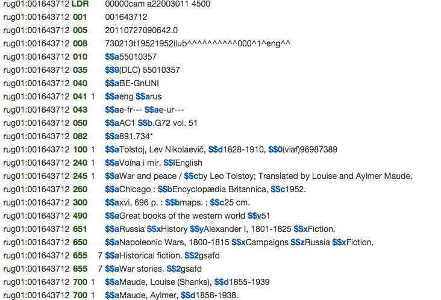

## MARC map

```
$ catmandu convert MARC --type USMARC to YAML < camel.usmarc
```

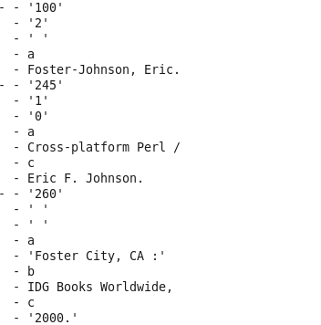

```
copy_field(record.17.5,title)  ???
marc_map("245a",title)  !!!
```

## MARC map

```
marc_map("FIELD[IND]SUBFIELD(S)",PATH,--OPT...)
```

```
marc_map("245",title) # Cross-platform Perl /Eric F. Johnson.
marc_map("245",title,join:" ") # Cross-platform Perl / Eric F. Johnson.
marc_map("245ac",title,join:" ") # Cross-platform Perl / Eric F. Johnson.
marc_map("245ca",title,join:" ") # Cross-platform Perl / Eric F. Johnson.
marc_map("245ca",title,join:" ",pluck:1)
      # Eric F. Johnson. Cross-platform Perl /
marc_map("245a",title) # Cross-platform Perl

marc_map("655a", subject.$append)
```

```
$ perldoc Catmandu::Fix::marc_map
```

## Exercise 4

## RDF

SUBJECT PREDICATE OBJECT

```
http://en.wikipedia.org/wiki/Albert_Einstein
   http://purl.org/dc/elements/1.1/creator
      http://en.wikipedia.org/wiki/Theory_of_relativity
```

```
http://lib.ugent.be/record/012918219 dct:title "War and Peace"
http://lib.ugent.be/record/012918219 dct:creator "Leo Tolstoy"
http://lib.ugent.be/record/012918219 dct:identifier "1400079985"
http://lib.ugent.be/record/012918219 dct:identifier 978-1400079988
```

```
SELECT subject WHERE { ?subject dct:creator "Leo Tolstoy" }
```

## Catmandu RDF

```
---
_id: http://lib.ugent.be/record/012918219
dct_title: "War and Peace"
dct_creator: "Leo Tolstoy"
dct_identifier:
    - 1400079985
    - 978-1400079988
```

```
$ catmandu convert YAML to RDF --type NTriples --fix myfixes.fix < test.yaml

$ catmandu convert MARC to RDF --type NTriples --fix marc.fix < data.mrc
```

```
http://lib.ugent.be/record/012918219 dct:identifier "1400079985"

http://lib.ugent.be/record/012918219 dct:identifier usn:isbn:1400079985
```

## Exercise 5

## RDF Reconciliation

Reconciliation is identifying multiple representations of the same real-world object.

- Dostoyevsky
- Dostoevskij
- Dostojevskij
- Dostoievski

Who is the real Jan Jansen?

- Jansen, Jan
- Jansen, Jan
- Jansen, Jan

## VIAF http:://viaf.org

[figure not shown]

## VIAF LDF http://data.linkeddatafragments.org/viaf

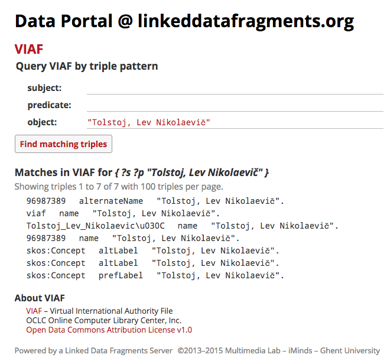

## Catmandu RDF

```
catmandu convert RDF --url http://data.linkeddatafragments.org/viaf
   --sparql 'SELECT * {?s ?p "Einstein, Albert"}'
```

```
---
name: Einstein, Albert, 1879-1955
```

```
rdf_ldf_statements(name,
   url:"http://data.linkedatafragments.org/viaf",
   predicate:"http://schema.org/alternateName")
```

```
---
name:
  - http://viaf.org/viaf/75121530
```

## Exercise 6

## LDF Server

- NodeJS server https://github.com/LinkedDataFragments/Server.js
- HDT-cpp https://github.com/RubenVerborgh/hdt-cpp
- Generate NTriples with some tool (e.g. Catmandu)
- Run rdf2hdt on these triples to create a HDT file
- Create a config.json file
- Boot the ldf-server

## LDF Server config

```
{
  "title": "My Linked Data Fragments server",
  "datasources": {
    "rug01": {
      "title": "Catalog",
      "type": "HdtDatasource",
      "description": "Catalog sample",
      "settings": { "file":
      "/home/catmandu/LinkedDataFragments/data/rug01.hdt" }
    }
  },

  "prefixes": {
    "rdf":         "http://www.w3.org/1999/02/22-rdf-syntax-ns#",
    "rdfs":        "http://www.w3.org/2000/01/rdf-schema#",
    "xsd":         "http://www.w3.org/2001/XMLSchema#",
    "dc":          "http://purl.org/dc/terms/",
    "foaf":        "http://xmlns.com/foaf/0.1/",
    "dbpedia":     "http://dbpedia.org/resource/",
    "dbpedia-owl": "http://dbpedia.org/ontology/",
    "dbpprop":     "http://dbpedia.org/property/",
    "hydra":       "http://www.w3.org/ns/hydra/core#",
    "void":        "http://rdfs.org/ns/void#"
  }
}
```

## LDF Server boot

```
$ ldf-server config.json
```

## Exercise 7